# Rafael Santos Erbisti

### Bio

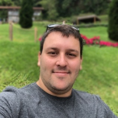

Professor do Departamento de Estatística

- **Doutorado em Estatística (UFRJ)**
- **Mestrado em Estatística (UFRJ)**
- **Bacharelado em Estatística (ENCE)**

Gabinete: 70 (Bloco G – Ala A – 4º andar)

### Posts

1-Workshop-Explorando-o-Tidyverse-main  
*O tidyverse é o grupo das bibliotecas mais conhecida e usadas do R, no tidyverse encontramos maneiras de tratar, limpar, manipular e visualizar dados de maneira otimizada, e nesse workshop vamos explorar.*

2-Workshop-ggplot2-main  
*A melhor maneira de visualizar dados é com um bom gráfico, e o pacote ggplot2 é o que nos ajuda a fazer os mais principais e variados gráficos, com uma sintaxe fácil e simples tal pacote é um dos mais utilizados no R e aqui veremos um pouco dele.*

3-Workshop-Mapas-Graficos-Interativos-main  
*As vezes queremos visualizar dados de maneira geográfica e no R temos bibliotecas que criam mapas de acordo com de onde e como queremos, aqui veremos um pouco desses pacotes iteressantes para nos localizarmos.*

4-Workshop-Introducao-RMarkdown-main  
*O R tem várias mecanicas, inclusive uma ferramenta exclusiva de escrever em latex, tendo sinergia com a programação o RMarkdown pode ser uma boa forma de se adaptar a fazer de tupo pelo R/Rstudio.*

5-Workshop-Relatorios-Interativos-main  
*Neste workshop mostramos como fazer relatórios interativos, de forma que o usuário consiga manipular e filtrar a forma com que visualiza os dados e estatísticas presentes em gráficos, tabelas e relatórios.*

## Endereço

Rua Prof. Marcos Waldemar de Freitas Reis s/n

Instituto de Matemática e Estatística – Bloco H – 5o. andar – Ala A

São Domingos, Niterói – RJ, CEP 24.210-201